# Higher treefall rates on slopes and waterlogged soils result in lower stand biomass and productivity in a tropical rain forest - Ferry - 2010 - Journal of Ecology - Wiley Online Library

[Datenschutz-Bestimmungen](https://www.wiley.com/privacy)

[Login / Register](https://besjournals.onlinelibrary.wiley.com/action/showLogin?role=button&uri=%2Fdoi%2Ffull%2F10.1111%2Fj.1365-2745.2009.01604.x)

[Journal of Ecology](https://besjournals.onlinelibrary.wiley.com/journal/13652745)

[Volume 98, Issue 1](https://besjournals.onlinelibrary.wiley.com/toc/13652745/2010/98/1) p. 106-116

[figure not shown]

Free Access

# Higher treefall rates on slopes and waterlogged soils result in lower stand biomass and productivity in a tropical rain forest

[Bruno Ferry](https://besjournals.onlinelibrary.wiley.com/authored-by/Ferry/Bruno),

*Correspondence author. E-mail:

[François Morneau](https://besjournals.onlinelibrary.wiley.com/authored-by/Morneau/Fran%C3%A7ois),

[Jean-Daniel Bontemps](https://besjournals.onlinelibrary.wiley.com/authored-by/Bontemps/Jean%E2%80%90Daniel),

[Lilian Blanc](https://besjournals.onlinelibrary.wiley.com/authored-by/Blanc/Lilian),

[Vincent Freycon](https://besjournals.onlinelibrary.wiley.com/authored-by/Freycon/Vincent),

First published: 11 December 2009

https://doi.org/10.1111/j.1365-2745.2009.01604.x

Citations: 133

## Summary

**1.** Relationships between tropical rain forest biomass and environmental factors have been determined at regional scales, e.g. the Amazon Basin, but the reasons for the high variability in forest biomass at local scales are poorly understood. Interactions between topography, soil properties, tree growth and mortality rates, and treefalls are a likely reason for this variability.

**2.** We used repeated measurements of permanent plots in lowland rain forest in French Guiana to evaluate these relationships. The plots sampled topographic gradients from hilltops to slopes to bottomlands, with accompanying variation in soil waterlogging along these gradients. Biomass was calculated for >175 tree species in the plots, along with biomass productivity and recruitment rates. Mortality was determined as standing dead and treefalls.

**3.** Treefall rates were twice as high in bottomlands as on hilltops, and tree recruitment rates, radial growth rates and the abundance of light-demanding tree species were also higher.

**4.** In the bottomlands, the mean wood density was 10% lower than on hilltops, the basal area 29% lower and the height:diameter ratio of trees was lower, collectively resulting in a total woody biomass that was 43% lower in bottomlands than on hilltops.

**5.** Biomass productivity was 9% lower in bottomlands than on hilltops, even though soil Olsen P concentrations were higher in bottomlands.

**6.** *Synthesis*. Along a topographic gradient from hilltops to bottomlands there were higher rates of treefall, which decreased the stand basal area and favoured lower allocation to height growth and recruitment of light-demanding species with low wood density. The resultant large variation in tree biomass along the gradient shows the importance of determining site characteristics and including these characteristics when scaling up biomass estimates from stand to local or regional scales.

## Introduction

Tropical lowland rain forests play a critical role in global carbon storage because they contain many high-biomass species and are highly productive (Lewis *et al.* 2009), but much uncertainty attends the estimation of rain forest biomass. Scaling up estimates of above-ground biomass requires steps from tree-level to stand-level, and thence to local or regional scales. The first step uses allometric equations linking the tree’s biomass to its diameter – and height when available – and to a proxy of its wood density, which is usually the specific mean value (Chave *et al.* 2005; but see Chave *et al.* 2008). The second step uses empirical relationships between environmental factors that are mapped in the study area and biomass-related stand characteristics. At the scale of the Amazon basin, basal area is negatively correlated to the length of the dry season (Malhi *et al.* 2006; Saatchi *et al.* 2007), and mean wood density increases from the relatively young and fertile soils of the foot of the Andean hills to the old and infertile soils of Central and NE Amazonia (Baker *et al.* 2004; Steege *et al.* 2006). At local scales, high variations in biomass have been reported, and a variety of possible environmental driving factors has been hypothesized that remain to be confirmed (Laurance *et al.* 1999; de Castilho *et al.* 2006; Paoli, Curran & Slik 2008).

A further and more comprehensive approach to assessing the distribution of forest biomass consists of studying spatial variations in net primary productivity, often estimated from the measurement of coarse wood productivity, and biomass loss through mortality. The spatial variations in net primary productivity of old-growth lowland moist tropical forests are mainly driven by soil fertility (Vitousek 1984; Malhi *et al.* 2004; Paoli & Curran 2007). In contrast, the spatial variations in mortality rate are driven by a variety of environmental factors like the high frequency of heavy rainfall (Nelson *et al.* 1994), steep slope (Robert 2003), slope exposure and wind (Bellingham & Tanner 2000), soil waterlogging (Scatena & Lugo 1996; Madelaine *et al.* 2007) and soil fertility (Phillips *et al.* 2004; Russo *et al.* 2005; Bellingham & Sparrow 2009). Moreover, environmental factors modify the mode of tree death: uprooting is more frequent in shallow or flooded soils because of more superficial root anchorage, whereas standing death is more frequent on ridges, possibly because of drier conditions (Durrieu De Madron 1994; Gale & Hall 2001; Lima & Moura 2008).

Above-ground productivity and forest biomass display a strong positive correlation globally, but the relationship is very weak when considering only the lowland old-growth tropical rain forests (Keeling & Phillips 2007). This indicates that spatial variations in mortality rate are likely to play a major role in determining the above-ground biomass of tropical rain forests. For example, negative correlations between background mortality rate and basal area are found in tropical rain forests at a global scale (Phillips *et al.* 1994) and landscape scale (Scatena & Lugo 1996). In contrast, a strong gradient in mortality rate across the Amazon basin has no effect on the basal area, but displays a negative correlation with the mean wood density of the stands, linked to the frequency of light-demanding species (Chao, Phillips & Baker 2008). The origin of these different patterns is, however, unknown. It could be linked to variable interactions between mortality and productivity. Examples of positive correlations are found across gradients in soil fertility or temperature (Stephenson & van Mantgem 2005), whereas negative correlations are observed in temperate monospecific plantations when thinning intensity varies (Skovsgaard 2009). In old-growth tropical moist forests, it was hypothesized that higher mortality could increase productivity, by making the stand younger and by increasing the frequency of light-demanding fast-growing species (Keeling & Phillips 2007).

The main goal of this study was to quantify the effects of a background mortality controlled by the environment on the biomass and productivity of an old-growth rain forest. It was conducted in the permanent plots of Paracou (French Guiana), characterized by a relatively low and uniform chemical fertility and by a large range of slope angle and soil waterlogging conditions.

Our hypotheses are: (i) tree mortality rates will increase as slope and soil waterlogging increase, and treefalls, as a mode of tree death, will also increase along these gradients, and (ii) higher tree mortality rate along the gradient will result in a lower stand basal area, a higher frequency of light-demanding species and therefore lower stand biomass.

## Materials and methods

### Study site

The study site is located in the Paracou experimental forest in French Guiana (Fig. 1). Elevation is between 5 and 50 m, and mean annual temperature is 26 °C, with an annual range of 1–1.5 °C. Rainfall averages 2980 mm a<sup>−1</sup> (30-year period) with a 3-month dry season (< 100 mm month<sup>−1</sup>) from mid-August to mid-November (Epron *et al.* 2006). The landscape is characterized by a patchwork of hills (100–300 m wide and 20–35 m high) separated by narrow streams. Slopes range from 25% to 50%. The parent material is a metamorphic formation of the Precambrian shield, characterized by schists and sandstones, locally crossed by veins of pegmatite, aplite and quartz. Soils are mostly acrisols (Epron *et al.* 2006), limited in depth by a transformed loamy saprolite (≤ 1 m deep), which has a low permeability and leads to lateral drainage during heavy rains. Upper permeable horizons are usually thickest on hilltops and shallowest in upper or mid-position along slopes (Barthes 1991). Bleaching of surface horizons resulting from seasonal waterlogging is strong along streams (gleysoils), but occurs also on the slopes, especially in their lowest parts.

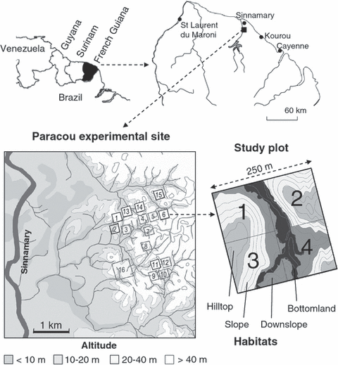

**Figure 1**

Open in figure viewer[PowerPoint](https://besjournals.onlinelibrary.wiley.com/action/downloadFigures?id=f1&doi=10.1111%2Fj.1365-2745.2009.01604.x)

Location of the study site and habitat map of a plot. Forest data come from the six whitened plots (1, 6, 11, 13, 14, 15); water-table depths were measured in four plots (1, 2, 6, 13); litter and soil samples were collected in four plots (7, 8, 10, 13).

The permanent plots (6.25 ha each, except one of 25 ha) were settled within a 400-ha area after a soil survey, allowing to ensure a relatively similar distribution of soils in the plots. The forest data used in this study come from six plots covered by undisturbed rain forest. Our soil studies (water-table depth, litter and soil chemical analyses) were partly carried out on these plots, and partly on others (see Fig. 1, for the plot lists and localization).

### Habitat mapping and characterization

Four habitats were identified with regard to their conditions in slope angle and soil waterlogging: hilltop (flat to gentle slope, soil waterlogging very rare), slope (medium to steep slope, low-intensity waterlogging), downslope (flat to gentle slope, medium-intensity waterlogging), bottomland (flat, high-intensity waterlogging). The limits between hilltop, slope and downslope were manually delineated on a topographic map, the slope habitat covering hillsides with a slope angle above *c.* 25% (Fig. 1). The limit between downslope and bottomland was determined by the presence of a permanent water-table in bottomland, no deeper than 1 m in the middle of the dry season (Gourlet-Fleury *et al.* 2004).

The fluctuations of the water-table depth in bottomlands during the rainy season were quantified with 43 piezometers, spread in the bottomlands of four plots. Twenty measurements were made from early April to July 2002, which happened to be an exceptionally rainy season. The time series of the mean water-table depth (from the 43 piezometers) was modelled as a function of daily rainfall data, collected a few kilometres from the forest plots. An empirical model, based on simple functions, was used to reconstruct a water-table depth chronology, every day from 1991 to 2007. It allowed us to calculate the longest periods per year of continuous water saturation at different depths.

Litter and soil chemical properties were compared between bottomlands and hilltops plus slopes. In both habitats, five litter samples and five soil samples 0–10 cm in depth were collected, each of them being a mixture of 10 subsamples scattered along a 60-m contour line. The soil subsample was collected with an auger. The litter subsample contained 10 leaves collected manually from the ground litter, as fresh as possible and belonging to a variety of species. Soil analyses included pH, exchangeable cations (Ca, K, Mg, Na, Al and H) extracted by cobalt hexamine chloride at soil pH (Ciesielski & Sterckeman 1997), available phosphorus extracted by the Olsen method, total nitrogen and organic carbon and particle size. Litter was analysed by measuring total C, N, P, Ca, Mg, K and Na.

### Stand data

Stand data were provided by exhaustive inventories of trees over 10 cm d.b.h. from 1991 to 2003. The mean annual rainfall of this period was close to the 30-year mean (2810 vs. 2980 mm), while the length of the dry season was slightly shorter (2.6 vs. 3 months). The girths were measured at 1.3 m or above buttresses, annually up to 1995 and then every 2 years (Gourlet-Fleury *et al.* 2004). Recruited and dead trees were always recorded annually. The type of natural death was recorded as standing death, primary treefall or secondary treefall (i.e. as a result of primary treefall).

Tree species were separated into light-demanding and shade-tolerant species, from a classification achieved to model the forest dynamics in response to experimental logging in nine other plots of Paracou (Favrichon 1998a) (Table S1 in Supporting Information). The mean characteristics of the light-demanding species display a faster diameter growth and a lower wood density than the other species.

Wood specific densities were obtained from a large data base compiled by CIRAD (Table S1). Wood densities at 12% moisture were converted into standard wood densities (i.e. oven-dry mass divided by green volume) through multiplication by the correction factor 0.861 (Muller-Landau 2004). For 66% of the trees, wood density was estimated by a mean species value. Otherwise, a mean value for the genus (15% of the trees), family (13%) or vernacular name (6%) was used. A standard wood density of 0.73 g cm<sup>−3</sup> was attributed to the remaining unidentified trees (0.1%).

Mortality or recruitment rates were calculated as the numbers of dead or recruited trees divided by the mean number of living trees (Sheil, Burslem & Alder 1995).

Coarse wood productivity was calculated as the biomass increment of the living trees plus the biomass of the recruited trees during the reference period (Malhi *et al.* 2004).

### Statistics

Statistical analyses were performed with S-Plus software, professional version 2000 (MathSoft Inc., Seattle, WA, USA).

## Results

### Soil characterization

This model allowed us to infer that the ‘mean bottomland soil’ is rarely saturated for more than 5 days above 20 cm and that it was not saturated more than 6 days above 10 cm during the exceptionally wet year of 2002 (Table 1).

Table 1. Interannual variability in maximum duration of continuous water saturation in bottomland, at different depths of the soil, from 1991 to 2007. The daily water-table depth is an estimation from daily records of rainfall and eqn (1) of the mean water-table depths of the 43 piezometers in bottomland

|  | Maximum duration (in days) per year of continuous soil waterlogging at a depth of: 10 cm | Maximum duration (in days) per year of continuous soil waterlogging at a depth of: 20 cm | Maximum duration (in days) per year of continuous soil waterlogging at a depth of: 30 cm |
| --- | --- | --- | --- |
| Median | 1 | 4 | 12 |
| Upper quartile | 2 | 5 | 45 |
| Maximum | 6 | 57 | 81 |

Chemical analyses of the litter and the surface soil indicated better availability of phosphorus in bottomland than on hilltop plus slope: +82% for the exchangeable phosphorus in soil and −29% for the C:P ratio in litter (Table 2). Total nitrogen content of the soil was lower in bottomland (−25%), but C:N ratios for soil and litter did not vary across habitats. Soil pH and base saturation of the cation exchange capacity were similar in both habitats, whereas the litter was richer in calcium and potassium in bottomlands.

Table 2. Comparison of soil and fresh litter analysis on hilltop plus slope versus bottomland (mean and standard error (in brackets), calculated from five samples in each topographic situation). Downslope was not sampled. Significant differences are indicated in the last row (**P* < 0.05; ***P* < 0.01). CEC, cation exchange capacity; BS, base saturation of CEC

|  | Soil (0–10 cm) Clay % | Soil (0–10 cm) C g kg<sup>−1</sup> | Soil (0–10 cm) N g kg<sup>−1</sup> | Soil (0–10 cm) C/N | Soil (0–10 cm) CEC cmol kg<sup>−1</sup> | Soil (0–10 cm) BS % | Soil (0–10 cm) pH | Soil (0–10 cm) P<sub>Olsen</sub> mg kg<sup>−1</sup> | Fresh litter C:N | Fresh litter C:P | Fresh litter N:P | Fresh litter C:Ca | Fresh litter C:K |
| --- | --- | --- | --- | --- | --- | --- | --- | --- | --- | --- | --- | --- | --- |
| Hilltop + slope | 24.4 (3.1) | 31 (3) | 1.9 (0.1) | 16.2 (0.4) | 2.8 (0.2) | 23 (1) | 4.6 (0.0) | 4.4 (0.4) | 44.7 (1.0) | 2655 (182) | 60 (4) | 90 (12) | 515 (23) |
| Bottomland | 12.8 (2.1) | 23 (2) | 1.4 (0.1) | 15.8 (0.5) | 2.0 (0.2) | 23 (1) | 4.7 (0.1) | 8.0 (0.7) | 43.3 (0.8) | 1894 (122) | 44 (2) | 51 (4) | 382 (24) |
| *t*-Test | * | * | * |  | * |  |  | ** |  | ** | ** | * | ** |

### Forest dynamics

#### Mortality

Stand mortality rates were slightly greater on slopes and downslopes than on hilltops (*P* < 0.01, Table 3), but were much greater on bottomlands than any position upslope (*P* < 0.001). The treefall mortality increased by a factor of two across habitats, whereas the standing death did not vary at all. Primary and secondary treefalls both increased significantly from hilltop to bottomland, but secondary treefalls displayed a significantly higher increase.

Table 3. Forest dynamics from 1991 to 2003. Standard errors are in brackets. Significant differences among habitats are indicated by different lower case letters. ‘Treefall ratio 2:1’ means ‘ratio of the secondary treefall by the primary treefall mortality rates’

[output not shown]

Light-demanding species had a relatively high mortality rate, with little spatial variation across habitats (Fig. 2d). In contrast, shade-tolerant species displayed a significant increase of mortality rate from hilltop to slope plus downslope (*P* = 0.003) and from slope plus downslope to bottomland (*P* < 0.001). Treefall mortality rates displayed similar trends across habitats for both groups of species, but with more significant differences for shade-tolerant species (Fig. 2a,b). In contrast, standing death displayed two different patterns across habitats for the two species groups, with no spatial variations for shade-tolerant species, but a strong decrease in bottomland for light-demanding species (Fig. 2c).

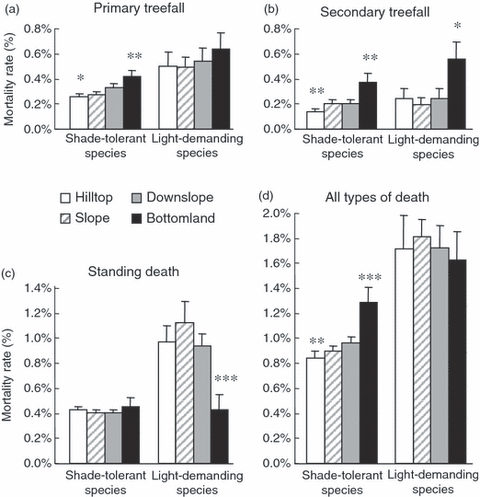

**Figure 2**

Open in figure viewer[PowerPoint](https://besjournals.onlinelibrary.wiley.com/action/downloadFigures?id=f2&doi=10.1111%2Fj.1365-2745.2009.01604.x)

Mortality rates of shade-tolerant species and light-demanding species in the different habitats, by (a) primary treefall, (b) secondary treefall, (c) standing death and (d) all types of mortality. Error bars are standard errors. Significant differences from hilltop or bottomland to slope plus downslope are indicated by stars (**P* < 0.05; ***P* < 0.01; ****P* < 0.001).

#### Recruitment

The recruitment rate showed a similar increase from hilltop to bottomland as the mortality rate, but had lower values (Table 3). The difference between mortality and recruitment rates did not display any significant effect of habitats.

#### Diameter growth of the trees and coarse wood productivity of the stand

The mean diameter growth of the trees increased by 58% from hilltop to bottomland, with significant differences (*P* < 0.001) between hilltop and slope plus downslope, and between slope plus downslope and bottomland (Table 3).

The above-ground biomass productivity decreased moderately from hilltop to bottomland (−9.2%), with a significant difference between hilltop and slope plus downslope (*P* = 0.018).

### State of the forest

#### Height–diameter relationship and new estimation of the above-ground biomass

The best model predicting the relationship of tree total height to its diameter at 1.3 m (or above the buttresses) was: *H* = *a*Ln(*D*) − 10.89, with *a* varying across habitats.

The slope (*a*) decreased significantly from hilltop and slope (9.934) to downslope (9.536), and from downslope to bottomland (9.198), whereas no difference could be found between hilltop and slope (Fig. 3). The big trees were therefore shorter downslope than on hilltop and slope at a given diameter, and even shorter in bottomland.

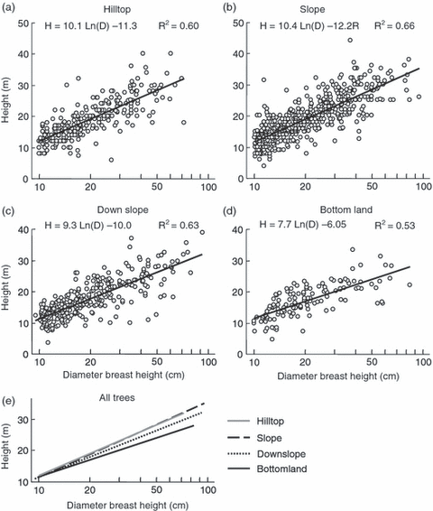

**Figure 3**

Open in figure viewer[PowerPoint](https://besjournals.onlinelibrary.wiley.com/action/downloadFigures?id=f3&doi=10.1111%2Fj.1365-2745.2009.01604.x)

Diameter–height allometries in (a) hill top, (b) slope, (c) down slope, (d) bottomland, (e) all habitats. Hilltop and slope displayed almost the same regression line.

#### Characteristics in 2003 and changes from 1991

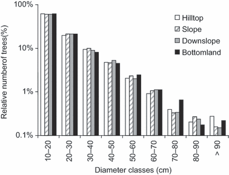

**Figure 4**

Open in figure viewer[PowerPoint](https://besjournals.onlinelibrary.wiley.com/action/downloadFigures?id=f4&doi=10.1111%2Fj.1365-2745.2009.01604.x)

Diameter structure of forest in the different habitats (total area: 37.5 ha).

All these characteristics except above-ground biomass displayed no significant difference between slope and downslope.

From 1991 to 2003, significant changes occurred in tree density (−2.2%), mean diameter (+2.2%), basal area (+2.1%) and biomass (+2.9%), but not wood density (0.0%). No significant difference across habitats could be detected in these changes.

## Discussion

### Effects of slope and soil waterlogging on mortality

Consistent with the prediction that soil waterlogging and slope would increase the mortality rate and particularly the treefall mortality rate, our results showed a twofold increase in treefall mortality rate from hilltop to bottomland, whereas the standing mortality rate was unchanged. In addition, our data indicated an increasing ratio of secondary to primary treefall from hilltop to bottomland (Table 3).

The higher frequency of primary treefall in the waterlogged areas probably results from a more superficial root anchorage of the trees and from a lower soil gear strength (Durrieu De Madron 1994; Gale & Barfod 1999; Gale & Hall 2001). The increase in mortality rate from hilltop to bottomland in Paracou was slightly lower than that calculated in another permanent plot in French Guyana (Madelaine *et al.* 2007).

The increase in treefall mortality rate from hilltop to slope together with no variation in the standing mortality rate (Table 3) is consistent with predictions of a model of the effects of slope angle on mortality rates, with or without treefall occurrence in the model (Robert 2003). The key assumptions of this model are that (i) a tree in a sloping area develops longer branches towards downslope because there is more light (Sumida *et al.* 2002) and (ii) an asymmetrical crown increases the probability of a tree falling down towards the gravity centre of the crown (Young & Hubbell 1991; Young & Perkocha 1994). Such a mechanism implies that treefall occurs preferentially towards downslope (Robert 2003), and is consistent with the increasing ratio of secondary to primary treefall from hilltop to bottomlands (Table 3).

We found that the frequency of low-wood-density light-demanding species increased from hilltop to bottomland. It could help to explain the extent of the mortality gradient, as light-demanding species have higher mortality rates *per se* than shade-tolerant species (Wright *et al.* 2003; Chao, Phillips & Baker 2008; Chave *et al.* 2009). The gradient in mortality rate across habitats, however, was no higher for the whole stand (Table 3) than for the shade-tolerant species only (Fig. 2d). Therefore, the frequency gradient in light-demanding species did not strengthen the mortality gradient. This surprising result stems from the strong decrease in mortality rate from standing death of the light-demanding species in bottomland (Fig. 2c).

The recruitment rate was less than the mortality rate during the study period, and the comparisons of the stand characteristics between 1991 and 2003 showed a slight decrease of the stand density, but a slight increase of the mean tree diameter, of the basal area and of the above-ground biomass. We did not find a clear interpretation for these changes, which are similar to that observed in a neighbouring permanent plot (Madelaine *et al.* 2007), but fit only in part the mean regional pattern (Lewis *et al.* 2004). They probably did not result from particular climatic conditions, as the annual rainfall and the length of the dry season were close to those of the 30-year reference period. All these changes over time within habitats were, however, independent of the habitats and minor compared with spatial variations between habitats. In addition, the very similar diameter distribution of forest across habitats (Fig. 4) indicates that there is no bias owing to a past disturbance that would have modified one habitat more than another (Coomes & Allen 2007). This reasoning allows for an interpretation of the variations in forest characteristics across habitats (in 2003) as resulting from the measured dynamics from 1991 to 2003.

### Soil fertility and coarse wood productivity of the stand

Our data showed a moderate decrease of the coarse wood productivity from hilltop to bottomland, with a significant difference between hilltop and other habitats (Table 3). This result is not consistent with the widely admitted hypothesis that coarse wood productivity is enhanced by a higher soil fertility (Malhi *et al.* 2004), especially by a higher soil-available phosphorus content (Paoli, Curran & Zak 2005; Paoli & Curran 2007). Our alternative hypothesis is that the frequency of stand canopy opening by mortality is a main factor driving stand productivity. Indeed, canopy opening reduces the leaf area index (Clark *et al.* 2008), which is an essential determinant of ecosystem productivity (Asner, Scurlock & Hicke 2003). Yet, this explanation also suggests that the decrease in coarse wood productivity should be higher between slope and bottomlands than between hilltop and slope, whereas the opposite is observed. This contradiction could arise from a positive effect of fertility on productivity in bottomlands, partially compensating for the negative effect of the more frequent canopy openings.

This reported negative relationship between mortality rate and coarse wood productivity (Fig. 5d) contrasts with positive correlations between forest turnover and productivity across fertility gradients at global and regional scales (Stephenson & van Mantgem 2005). Three mechanisms have been proposed by these authors to explain these positive correlations. First, fertility should improve the stand productivity, leading to a more intense competition among trees, and therefore to a higher mortality rate. Secondly, fertility could directly increase the mortality rate by favouring the organisms that attack plants, leading to a younger and more productive forest (Pregitzer & Euskirchen 2004). Thirdly, fertility could favour fast-growing short-lived species, contributing to a higher productivity and a higher mortality rate of the stand. Our study strongly suggests that the second and third mechanisms could not lead to a positive correlation between productivity and turnover. It is therefore likely that the positive correlations between forest turnover and productivity observed across fertility gradients are mostly driven by a positive effect of fertility on productivity.

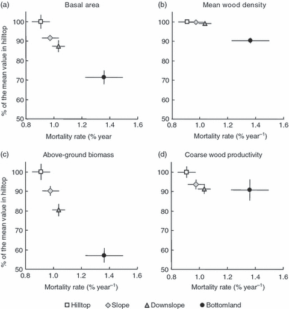

**Figure 5**

Open in figure viewer[PowerPoint](https://besjournals.onlinelibrary.wiley.com/action/downloadFigures?id=f5&doi=10.1111%2Fj.1365-2745.2009.01604.x)

Relationships between the mortality rates and the relative variations across habitats of (a) the basal area, (b) the wood density, (c) the above-ground biomass, (d) the coarse wood productivity of the stands. Values are means across habitats ± SE, divided by the mean hilltop value except for the mortality rate.

We suggest that a positive versus negative relationship between turnover and productivity in a sample of forest stands indicates whether the forest dynamics in this sample is driven by productivity or mortality.

### Variations in above-ground biomass across habitats

We found that the above-ground biomass dramatically decreased from hilltop to bottomlands, with significant differences across all habitats. It was a cumulative effect of three convergent decreases, in basal area, in wood density and in the H:D ratio of the big trees (Table 4, Fig. 3).

Table 4. Forest characteristics across habitats in 2003. Standard errors are in brackets. Significant differences among habitats are indicated by different lower case letters

| Habitat | Area (ha) | Number of subplots | Number of trees (ha<sup>−1</sup>) | Mean diameter (cm) | Basal area (m<sup>2</sup> ha<sup>−1</sup>) | Frequency of light-demanding species (%) | Wood density (g cm<sup>−3</sup>) | AGB (mg ha<sup>−1</sup>) |
| --- | --- | --- | --- | --- | --- | --- | --- | --- |
| Hilltop | 9.8 | 10 | 689 (19)<sup>a</sup> | 21.9 (0.3) | 35.9 (1.3)<sup>c</sup> | 6.0 (0.6)<sup>a</sup> | 0.741<sup>a</sup> (0.006) | 428<sup>a</sup> (17) |
| Slope | 13.5 | 11 | 638 (11)<sup>b</sup> | 22.1 (0.2) | 32.9 (0.5)<sup>b</sup> | 7.8 (0.6)<sup>b</sup> | 0.739<sup>b</sup> (0.004) | 386<sup>b</sup> (9) |
| Downslope | 9.3 | 10 | 618 (20)<sup>b</sup> | 21.9 (0.3) | 31.4 (1.0)<sup>b</sup> | 8.6 (0.5)<sup>b</sup> | 0.734<sup>b</sup> (0.004) | 343<sup>c</sup> (14) |
| Bottomland | 4.4 | 9 | 500 (22)<sup>c</sup> | 22.0 (0.3) | 25.6 (1.3)<sup>a</sup> | 22.8 (2.5)<sup>c</sup> | 0.669<sup>c</sup> (0.010) | 244<sup>d</sup> (15) |

The decrease in basal area from hilltop to bottomland is necessarily caused by the increase in mortality rate, as it cannot be accounted for by the parallel increases in recruitment rate and mean diameter growth. Such a negative correlation between the mortality rate and the basal area has already been recorded for tropical forests (Phillips *et al.* 1994; Scatena & Lugo 1996).

The increasing frequency of low-wood-density light-demanding species from hilltop to bottomland, leading to a decrease of the mean wood density of the stands (Table 4), is consistent with our prediction, as an outcome of the frequency of canopy openings by treefall. Light is very likely to be the main ecological driver of this gradient, as the frequency of our light-demanding group is similarly increasing in response to experimental openings of the canopy (Favrichon 1998b). Soil waterlogging, however, could also help in positive selection of the light-demanding species, assuming there is a trade-off between shade tolerance and flood tolerance among species. Such a trade-off has been reported in temperate forests (Battaglia & Sharitz 2006; Niinemets & Valladares 2006), while a positive correlation has been observed in tropical moist forest between flood tolerance and high photosynthetic capacity (Baraloto *et al.* 2007) as an attribute of light-demanding species (Holscher *et al.* 2006). The higher availability of phosphorus in bottomlands could also contribute to the higher frequency of the light-demanding species, as growth of these species is more responsive to nutrient supply (Lawrence 2003).

The decreasing slenderness of the big trees from hilltop to bottomland is consistent with the observation made in other rain forests that trees are more slender in denser stands, because competition for light is incitative of growth in height (Nogueira *et al.* 2008; King *et al.* 2009).

In conclusion, the three main stand characteristics determining above-ground biomass show variations across habitats that are mainly controlled by the canopy opening, and therefore by mortality rate (Fig. 5).

The above-ground biomass displayed higher relative range across habitats in Paracou than in the whole Amazonian basin (Malhi *et al.* 2006). In contrast, the range in mortality rate is much narrower in Paracou than in Amazonia (Phillips *et al.* 2004). The relationship between mortality rate and above-ground biomass is therefore very different on the local and regional scales. The Amazonian gradient in mortality rate is, however, positively correlated with a gradient in coarse wood productivity driven by soil fertility (Malhi *et al.* 2004; Stephenson & van Mantgem 2005). Basal area does not vary across this mortality–productivity–fertility gradient, probably because mortality and productivity have opposite effects, but across a gradient of the length of the dry season (Malhi *et al.* 2006). It demonstrates that the wide range in biomass displayed in Paracou comes (i) from a relatively moderate range in mortality rate and (ii) from the negative correlation between mortality rate and coarse wood productivity, as fertility is not a main driver of the spatial variations of forest dynamics.

## Conclusion

The Paracou permanent plots provide a good example of a system mainly driven by background mortality across topography. Soil waterlogging and slope angle are the primary ecological drivers, controlling the rate of treefall mortality and therefore inducing a strong light gradient. The system is characterized by a negative relationship between turnover and productivity, and by a very strong gradient in above-ground biomass.

The magnitude of biomass variations reported at local scale suggests strong uncertainties in global biomass estimates and the importance of determining site characteristics and including these characteristics when scaling up biomass estimates from stand to local or regional scales.

## Acknowledgements

We thank CIRAD-Forêt for permission to conduct research at the Paracou experimental site, and Silvolab-Guyane/UMR EcoFoG for the use of facilities in Kourou. We are grateful to Pascal Petronelli and the CIRAD inventory team for their work on tree inventories and botanical identification, to Jacques Beauchêne and Ervan Rutishauser for supplying the wood density data base, and to Damien Bonal, Jean Yves Goret and Jean-Louis Pradon for providing the rainfall data. Special thanks go to Anne Salvado, Michel Baisie and Bruno Janet for their fieldwork on water-table depth measurements. We also thank Christopher Baraloto and Benoît Renaux, and also the Handling Editor and three anonymous referees for helpful comments.

## Citing Literature

[Volume98, Issue1](https://besjournals.onlinelibrary.wiley.com/toc/13652745/2010/98/1)

January 2010

Pages 106-116

Citation Statements

beta

- Supporting

  Supporting12
- Mentioning

  Mentioning179
- Contrasting

  Contrasting2

Explore this article's citation statements on [scite.ai](https://scite.ai/reports/higher-treefall-rates-on-slopes-bdr18Z)

powered by

[figure not shown]

### Recommended

- [Wind‐throw mortality in the southern boreal forest: effects of species, diameter and stand age](https://besjournals.onlinelibrary.wiley.com/doi/full/10.1111/j.1365-2745.2007.01301.x)

  [Journal of Ecology](https://besjournals.onlinelibrary.wiley.com/journal/13652745)
- [Bark traits and life‐history strategies of tropical dry‐ and moist forest trees](https://besjournals.onlinelibrary.wiley.com/doi/full/10.1111/1365-2435.12158)

  [Functional Ecology](https://besjournals.onlinelibrary.wiley.com/journal/13652435)
- [Tropical forest wood production: a cross‐continental comparison](https://besjournals.onlinelibrary.wiley.com/doi/full/10.1111/1365-2745.12263)

  [Journal of Ecology](https://besjournals.onlinelibrary.wiley.com/journal/13652745)
- [Improved allometric models to estimate the aboveground biomass of tropical trees](https://onlinelibrary.wiley.com/doi/full/10.1111/gcb.12629)

  [Global Change Biology](https://onlinelibrary.wiley.com/journal/13652486)
- [Water table depth modulates productivity and biomass across Amazonian forests](https://onlinelibrary.wiley.com/doi/full/10.1111/geb.13531)

  [Global Ecology and Biogeography](https://onlinelibrary.wiley.com/journal/14668238)

[Download PDF](https://besjournals.onlinelibrary.wiley.com/doi/pdf/10.1111/j.1365-2745.2009.01604.x)

back